# **Project - Classification and Hypothesis Testing: Hotel Booking Cancellation Prediction**

### **Random Forest**

#### **Build a Random Forest Model**

```python
rf_estimator = RandomForestClassifier( random_state = 1)

rf_estimator.fit(X_train, y_train)
```

```
RandomForestClassifier(random_state=1)
```

#### **Check the performance of the model on the train and test data**

```
              precision    recall  f1-score   support

           0       0.99      1.00      1.00     17073
           1       1.00      0.99      0.99      8319

    accuracy                           0.99     25392
   macro avg       0.99      0.99      0.99     25392
weighted avg       0.99      0.99      0.99     25392
```

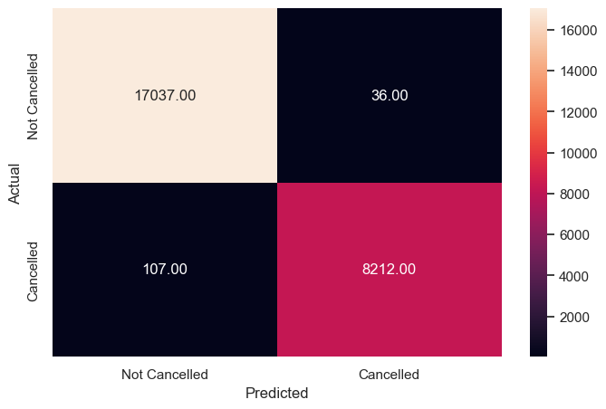

```python
y_pred_train_rf = rf_estimator.predict(X_train)

metrics_score(y_train, y_pred_train_rf)
```

- Almost 0 errors on the training set, almost each sample has been classified correctly.
- Model has performed very well on the training set.

```
              precision    recall  f1-score   support

           0       0.91      0.95      0.93      7317
           1       0.88      0.80      0.84      3566

    accuracy                           0.90     10883
   macro avg       0.90      0.88      0.88     10883
weighted avg       0.90      0.90      0.90     10883
```

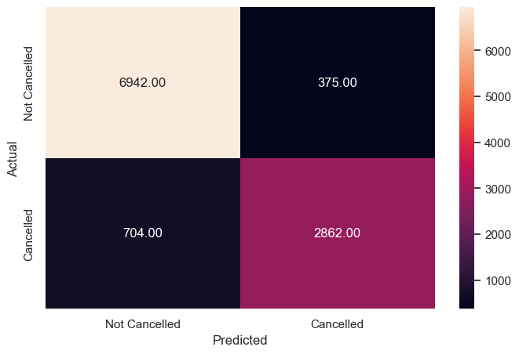

```python
y_pred_test_rf = rf_estimator.predict(X_test)

metrics_score(y_test, y_pred_test_rf)
```

Let's check the feature importance of the Random Forest

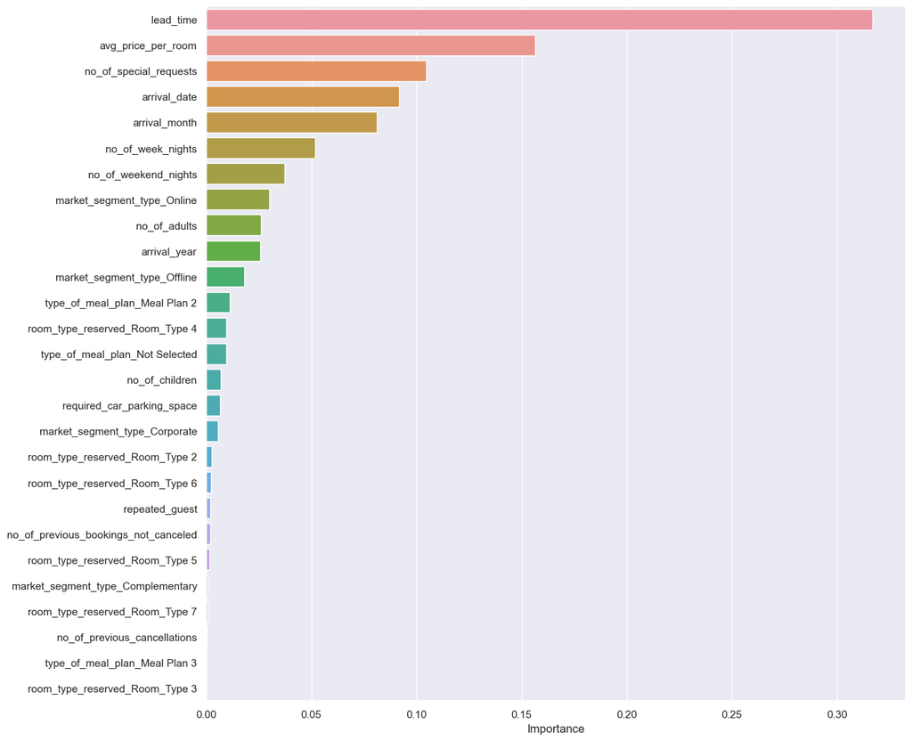

```python
importances = rf_estimator.feature_importances_

columns = X.columns

importance_df = pd.DataFrame(importances, index = columns, columns = ['Importance']).sort_values(by = 'Importance', ascending = False)

plt.figure(figsize = (13, 13))

sns.barplot(importance_df.Importance, importance_df.index)
```

- This seems more balanced and lets us see that also other variables have some importance.
- Lead time is still by far the most important variable, but the average price became the second most important one, meaning that the higher the price the higer the chance the room will be cancelled. Market segment type online seem to have lost some importance, while are pretty important the arrival date and month.
- The Random Forest partially verifies the results from the decision tree
- The number of special requests is important

### **Takeaways**

- Lead time is of extreme importance and is also positevly correlated with booking status, so we should do something about that. One solution could be to set a target lead time (for example Q3 = 126 days) and if a customer wants to book his room before than that, he needs to pay a deposit, in order to disincentivise him from cancel it.
- It seems like there's a positive correlation between being a repeated guest and having few canceled bookings, so we should do something to encourage our guests to become repeated guests, offering discounts or other advantages during their next staying.
- The general trend is that the chances of cancellation increase as the number of days the customer planned to stay at the hotel increases, so we might require a deposit also for guests that plan on staying for longer periods, or maybe give them a discount to increase the chances that they'll decide to come.
- Really few guests come to the hotel in january, february and march, so we could apply some discounts to encourage people to come, for example the lower prices could be inviting for younger people that have more free time but less money to spend. This of course have nothing to do with cancellations but it could increase the guests during months with few customers.
- The corporate segment also have really few cancellations so we should increase the number of rooms that are desireable for the guests of that segment
- The number of special requests is positively correlated to booking cancellations, which is bad because someone that cancels after asking for more things is an even bigger damage for our business. I think we should ask for an extra fee that those with special requests need to pay in advance.